# Coding Smart in Academia PhD Project

31/10/2022

## HOW TO (RE-)USE THIS MATERIAL

This is a `.html` presentation created in `R Markdown` with `ioslides`.

(It’s been written in a [.Rmd](http://rmarkdown.rstudio.com) file, and I generated .html slides by ‘knitting’ it in Rstudio.)

You can check out the code used to make these slides at the [Talk repo](https://github.com/FlicAnderson/PhD10moReview) on Github, and adapt it for your own presentations if you like - there’s a MIT Licence on the repo, which means:

*“Basically, you can do whatever you want as long as you include the original copyright and license notice in any copy of the software/source.”*

Source: [tl;drLegal](https://tldrlegal.com/license/mit-license)

## Coding Smart in Academia: *Evidence-Based Software Engineering Approaches for High-Quality Research Software Projects*

## Outline

**Project Background:**  
- motivation  
- main question, areas of focus  
- aims & goals  
- project development  
- main research questions

**Progress:**  
- what I’ve achieved so far  
- project plan summary  
- next 6 months priorities  
- challenges for me and the project  
- my questions

**RS: Research software**  
**SE: Software engineering**

## Project Background

## Project Motivation

**Research Software: *“any code written or software used in the process of generating results for a publication”***

- Software underpins (~) all modern research!
- Inaccuracies or inefficiencies in RS can have **negative research impacts** (calibration blind-spot)
- **RS often created by developers un-trained in SE**: majority informally- or self-taught; existing training is sporadic, not evidence-based
- Due to **diversity of RS projects**, identifying effective, appropriate SE approaches can be challenging
- *RS research lacks empirical evidence base identifying and supporting proven best practices*

## Project Question

*“Which **effective SE approaches*** prevalent in traditional SE can be recommended to **small research software projects within the UK** to improve their **software quality** and **development efficiency**?”*

*Areas of focus:*

- Software Engineering Approaches in Research Software [SEA]
- Measuring Research Software [RSM]
- Research Software Projects [RSP]

* Specific **SE techniques** and more general **SE development practices**.

## Project Aims

**Aims:**

- To develop RS **assessment metrics**.
- To use these in *small-scale UK-based RS projects* to **empirically test** whether specific SE recommendations are effective and improve RS development.

**Goals:**

- Develop **evidence-basis** to guide future researcher-developers in using effective SE approaches in their RS projects.
- Feed **SE recommendations back to RS community** through publications and presentations.

## Project Development So Far

Original Research Proposal:

- Focused on **SE in industry** (later considered use of SE approaches in start-ups).
- Would **use interview/surveys** of RS projects to investigate SE approaches being used in RS.
- **Less clarity** on definition of ‘effectiveness’ of SE techniques.
- Planned to include research on whether **methods for knowledge transfer** affected uptake of or effectiveness of specific SE techniques in RS projects.
- Emphasised using **taxonomy to compare RS projects**.
- Aimed to generate **comprehensive catalogue of programming techniques** used in RS projects.

## Progress

## What I’ve Achieved so Far (Project)

- **Refining research area** and extending research proposal
- **Skills development** (IAD courses)
- **Project planning** and **identifying key experiments**
- **Planning and designing experiment:** *Research Software Testing Experiences Survey*
- Made a start on **ethics process** for survey experiment and thinking about data management
- **Networking**: Meeting researchers, RS community members and software developers / technical leads from industry…
- **Literature Review** - broad background reading on RS research, comparisons to SE research, some methods studies, initial focus on measuring software quality

## What I’ve Achieved so Far: Lit Review

**Research Software Research…**

- … is a **young field** - there is much more SE research than RS research.
- … is **still exploratory**: establishing “what are RS practices?” and “who develops RS?”, rather than “how can we improve RS?”.
- … **rarely mentions Arts & Humanities** research projects and largely comprises work in scientific fields.
- … **contains multitudes** - RS measurement metrics need to account for differing goals and resources of RS projects compared with SE projects; research can include (large) Open Source Software studies, making comparison of findings regarding efficacy of SE approaches difficult.

## What I’ve Achieved so Far: Lit Review

- **Little replication within RS research** thus far.
- **N.U. Eisty & J.C. Carver** (Alabama) seem to have closest overlapping research interests. This project could *replicate/expand some of their methods with UK focus*, cf. US (+/- international) focus.
- RS research is **rarely backed by empirical data** and **sampling is often not robust** - *“generalizability crisis”* (Baltes & Ralph, 2021).
- Many studies **use only one method**; in many cases the **method doesn’t match the aims** of the research (e.g. many studies aim to benefit developers, but only use data-driven methods which don’t link back to the aims - Storey *et al.*, 2020). **Selecting appropriate mixed methods will address this.**

## What (Else) I’ve Achieved so Far

- **Volunteered at [Sixth Annual Conference for Research Software Engineering](https://rsecon2022.society-rse.org/)** (RSECon22)
- **Attended [SSI Collaborations Workshop 2022](https://www.software.ac.uk/cw22)** (CW22)
- **Applied for [SSI Fellowship Programme 2023](https://www.software.ac.uk/programmes-and-events/fellowship-programme)** to plan / organise activities relating to improving research software (shortlist confirmed ~Tuesday!)
- **Lead-authored** / coordinated SSI blog post* resulting from speed-blog group session at CW22

* = [Aim for understandability if you want to write good research software](https://www.software.ac.uk/blog/2022-07-04-aim-understandability-if-you-want-write-good-research-software).

## What (Else) I’ve Achieved so Far

- **Presentation** on *Open Science in Student Research Projects* at [Edinburgh Open Research Conference 2022](https://edopenresearch.com/edinburghopenresearchconference/)
- **Demonstrating** on *Programming Skills* & *Fundamentals of Data Management* EPCC masters courses
- **Helper & Demonstrator** on [Ed-DaSH](https://edcarp.github.io/Ed-DaSH/) project workshops (Carpentries-style workshops: Data Science for Health and Biosciences)
- **Volunteered** at tech industry/ startups conference [Turing Fest 2022](https://www.turingfest.com/conference)
- Part of *winning team* at SSI CollabW22 hack-day :)

## Main Research Questions

- “**How can effectiveness / appropriateness of SE techniques and development practices be measured** in small UK-based RS projects?” *[RSM0]*
- “**Do identified SE techniques or development practices improve the quality and/or development efficiency of RS** if deployed within small UK-based RS projects?” *[SEA0]*
- “**Which project factors influence the adoption and effective use** of these recommended SE approaches in small UK-based RS projects?” *[RSP0]*

## Project Plan Summary

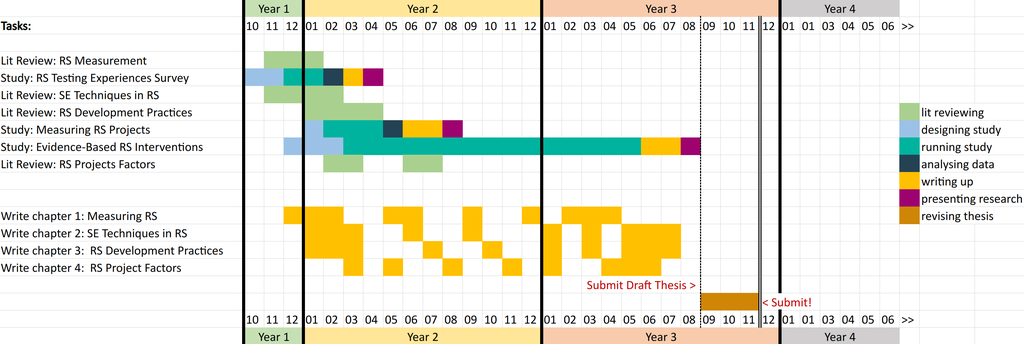

## Next 6 Months Priorities:

- Complete **ethics** procedures, create Data Management Plan
- *Lit Reviews:* **SE Approaches** (techniques + development practices)
- Run, analyse and write up RS **Testing Experiences** Survey
- *Lit Review:* **RS Measurement**
- Develop (+ **test** and refine) **RS assessment metrics** and methods
- Develop and refine **‘SE recommendations’** interventions
- **Recruiting** RS projects for Interventions study
- **Begin Evidence-Based RS Interventions** study

## Challenges for Me & The Project

**Collating a list of specific promising SE approaches to recommend in the Interventions study.**

They need to:  
- be quickly/easily learned with skill-up materials available  
- have supporting claims for their effectiveness  
- be likely to transfer well to RS projects  
- address software quality or development efficiency  
- have differing actions/methods of improvement  
- result in measurable changes in (6-9mo) intervention period

*Mitigations:* **Collate list** from lit reviews, survey study feedback, external datasets;  
**Gather feedback** on RS expectations/experiences re: likely effectiveness.

## Challenges for Me & The Project

**Recruiting appropriate RS projects for Interventions Study may be difficult.**

- High time commitment / engagement over several (~6-9) months;
- Developers may be reluctant to open up about ineffective behaviours or poor quality coding
- Potential difficulty in identifying RS projects from less familiar fields (e.g. Arts/Humanities/Social)
- Important to use high-quality sampling method

*Mitigations:* Offer **participation reward** vouchers; **share findings** on improving development and RS quality; (?programmatic?) **codebase measurement**/assessment methods to allow data collection without significant engagement by developers;

## Challenges for Me & The Project

**Project timescales are short for measuring changes to codebase and development.**

- Risk of not beginning long forward study Interventions experiment soon enough
- Delays to data collection
- difficulty in arranging interviews/meetings with key developers

*Mitigations:* Collate **list of potential projects** which may be likely to meet participation criteria, add/subtract from this as I refine criteria and verify availability or interest.  
**Stagger data collection** to spread the load over time.  
Focus on **sensitive metrics** which are likely to result in measurable changes relatively quickly.

## My Questions:

- Is the **“pre-intervention period vs intervention period” study design** worth the risks?
- How should I handle **studying more than one SEA recommendation** in the intervention study? Split study into: [Control, Rec1, Rec2, Rec3]? [Control vs Rec1+2+3]?
- **Are ‘control’ groups more likely to drop out** of intervention study?
- **How many projects are ‘practical’** to follow for ~1yr / account for drop-outs etc.?
- **How much compensation is ‘typical’** for taking part in a project like ‘Interventions’ study? What should I consider?